# Reproducible Workflow

## R code chunks

````
```{r name, options = ...}
1 + 1
```
````

```
## [1] 2
```

- Code chunks include code (mostly R but python is possible).
- Code is executed when knitting a R Markdown file.
- In R Studio you can use the shortcut `Ctrl + alt + i` to insert a code block.
- No underscore in chunk name, no name twice.

## Chunk options

- `eval = FALSE`
- `echo = FALSE`
- `warnings = FALSE`
- `cache = TRUE`
- `child = "rmdfilename.Rmd"`
- See [rmarkdown-cheatsheet2](https://github.com/jstbcs/ReproducibleWorkflowWorkshop/blob/master/material/rmarkdown-cheatsheet2.pdf) for most important options.

## Global chunk options

Adjust all chunk options in a Rmd file with the following command:

```r
knitr::opts_chunk$set(echo = TRUE)
```

## Task III

- Go back to your `Rmd` file.
- Add a chunk calculating the standard deviation (`sd()`) of the speed of cars.
- Print the results in a sentence below the chunk.
- Knit the PDF.
- Not happy with result? Round it!

## Inline R-Code

This is an inline expression `` `r sd(cars$speed)` `` in the output.

This is an inline expression 5.2876444 in the output.

## Inline R-Code

This is an inline expression `` `r sd(cars$speed)` `` in the output.

This is an inline expression 5.2876444 in the output.

```r
sdcars <- sd(cars$speed)
```

The standard deviation of the speed of cars is`` `r round(sdcars, 2)` ``.

The standard deviation of the speed of cars is 5.29.

## \(\mathbf{\LaTeX}\)

- You can add \(\mathbf{\LaTeX}\) code to your text.
- Math mode for formulas.

## \(\mathbf{\LaTeX}\)

- You can add \(\mathbf{\LaTeX}\) code to your text.
- Math mode for formulas.

```r
You can simply add a formular: $\frac{SD}{\sqrt{N}}$.
```

**Result:**

You can simply add a formular: \(\frac{SD}{\sqrt{N}}\).

## Math mode and R code

You can use R within math mode.

## Math mode and R code

You can use R within math mode.

```r
sd1 <- 15
n1 <- 17
```

## Math mode and R code

You can use R within math mode.

```r
sd1 <- 15
n1 <- 17
```

```r
$se = \frac{`r sd1`}{\sqrt{`r n1`}} \approx `r round(sd1/(sqrt(n1)), 2)`$
```

\(se = \frac{15}{\sqrt{17}} \approx 3.64\)

## 4. Writing an APA-style paper that is fully reproducible.

## `papaja`

- Template + filters + functions.
- Helps writing APA6 articles.
- Still in developement.
- More information: https://github.com/crsh/papaja.
- Example: material/example-paper.Rmd

File ➤ New File ➤ R Markdown ➤ From Template ➤ APA article

## `papaja`

### `apa_print`

Print statistical results.

```r
great_t_test <- t.test(1:10, y = c(7:20))
```

## `papaja`

### `apa_print`

Print statistical results.

```r
great_t_test <- t.test(1:10, y = c(7:20))
```

```r
The results were great, `r apa_print(great_t_test)$full_result`.
```

The results were great, \(\Delta M = -8.00\), 95% CI \([-11.05\), \(-4.95]\), \(t(21.98) = -5.43\), \(p < .001\).

## `papaja`

### Figures

For factorial design: Try apa_barplot & apa_beeplot.

```r
apa_beeplot(
  mixed_data
  , id = "Subject"
  , dv = "Recall"
  , factors = c("Task", "Valence", "Dosage")
  , dispersion = conf_int
  , ylim = c(0, 30)
  , las = 1
  , args_points = list(cex = 1.5)
  , args_arrows = list(length = 0.025)
)
```

## `papaja`

### Figures

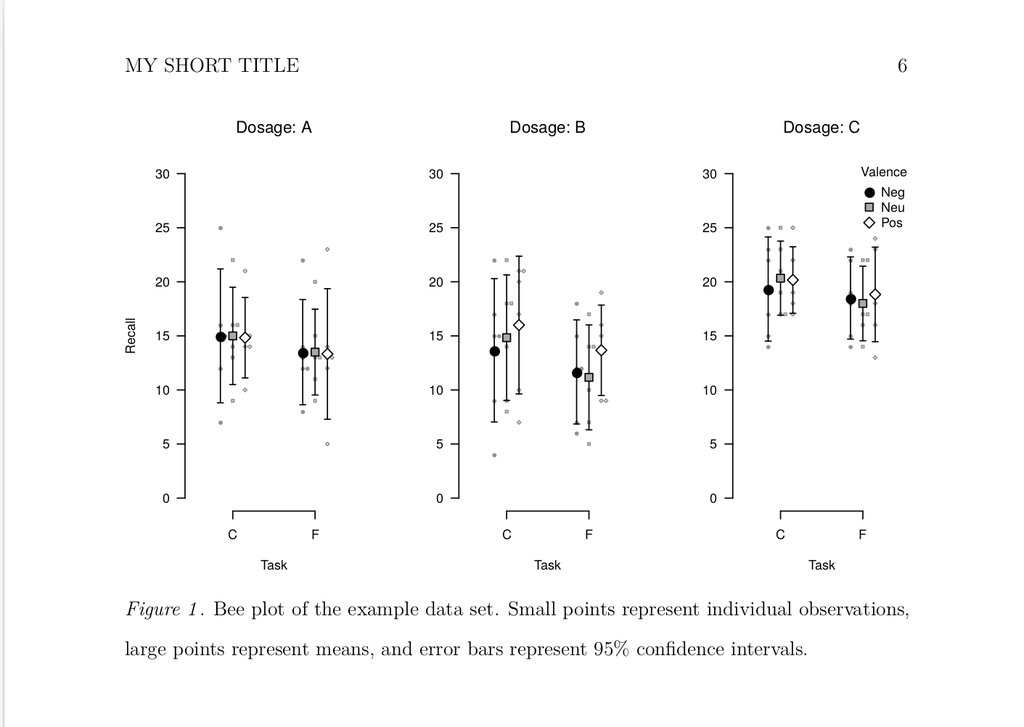

## `papaja`

### Figures

Figure reference and caption.

````
```{r some-fig, fig.cap = "Here is the figure caption."}
plot(seq(-2, 2, .01)
     , dnorm(seq(-2, 2, .01))
     , type = "l")
```
````

As can be seen in Figure `\@ref(fig:some-fig)`…

## `papaja`

### Tables

- Tables can be produced with R code in R chunks (e.g., with kable or apa_table).
- Important: add results=‘asis’ to chunk options.
- Tables can be written in Markdown directly.

## `papaja`

### Tables

```r
rnames <- LETTERS[1:4]
tvals <- runif(4, 0, 5)
n <- round(runif(4, 15, 100))
pvals <- pt(tvals, df = n - 1, lower.tail = F)
mytab <- data.frame(rnames, tvals, as.integer(n), printp(pvals))

apa_table(mytab
          , caption = "Results from four studies."
          , col.names = c("Study", "$t$-statistic", "Sample Size" , "$p$-value")
          , escape = F)
```

## `papaja`

### Tables

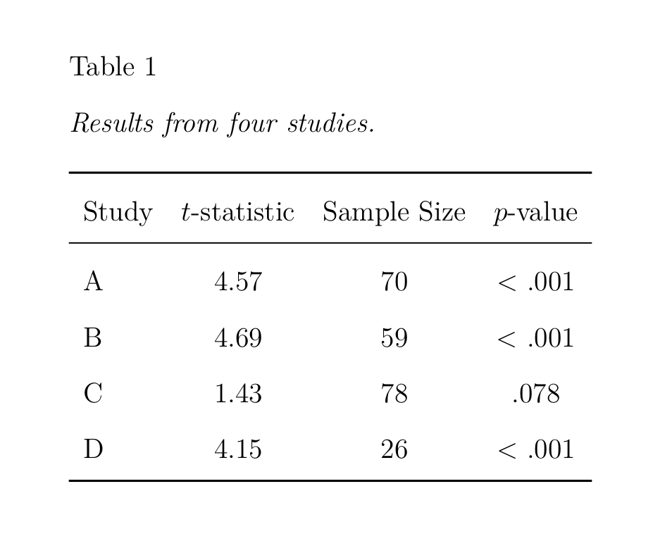

## `papaja`

### Sources and Citing

You need:

- A biblatex file of your references (e.g., from Zotero).
- Add .bib file name to `YAML` `bibliography: nameoffile.bib`.
- One way: Look up citation key and insert to text with @ in front.
- `@citationkey` for in-text and `[@citationkey]` for in-parentheses citation.
- Creates proper citation and reference list.

## `Citr`

- Save bib file and add to `YAML`.
- Install `citr` (RStudio plug-in).
- Set `citr` shortcut.
- More information: github.com/crsh/citr.

## Summary

## Summary

- You can do your analysis using `R Markdown`.
- It is convenient to integrate text and code.
- Upload Rmd, bib, data, and additional analysis files, and anyone can reproduce your analysis.
- Example paper: https://github.com/PerceptionAndCognitionLab/rm-gardiner-java.

## Summary

- You can do your analysis using `R Markdown`.
- It is convenient to integrate text and code.
- Upload Rmd, bib, data, and additional analysis files, and anyone can reproduce your analysis.
- Example paper: https://github.com/PerceptionAndCognitionLab/rm-gardiner-java

**Pro-tip:** If the R chunks are too long use `source()` to load `R`-files, and the chunk opion `child = myanalysis.Rmd` to include other `R Markdown` files.